# Homework 2

Krista Noe

2/15/2021

This homework is all about verifying output of a fitted linear model. We will use the same beach dataset from last homework. As before, start by fitting a model with OpenBeach as the response, and include an interaction between Year and BeachID.

```r
beach <- read.csv("beach.csv")
fit <- lm(OpenBeach ~ Year * BeachID, data = beach)
```

1. Calculate the residuals. Use the summary() function applied to your numeric vector of residuals to verify that this matches the Residuals: quantiles reported from the summary of your fitted model. Plot a histogram of your residuals. Do they appear reasonably Gaussian? (we will go into detail on formal model checking later in the semester) (5 points)

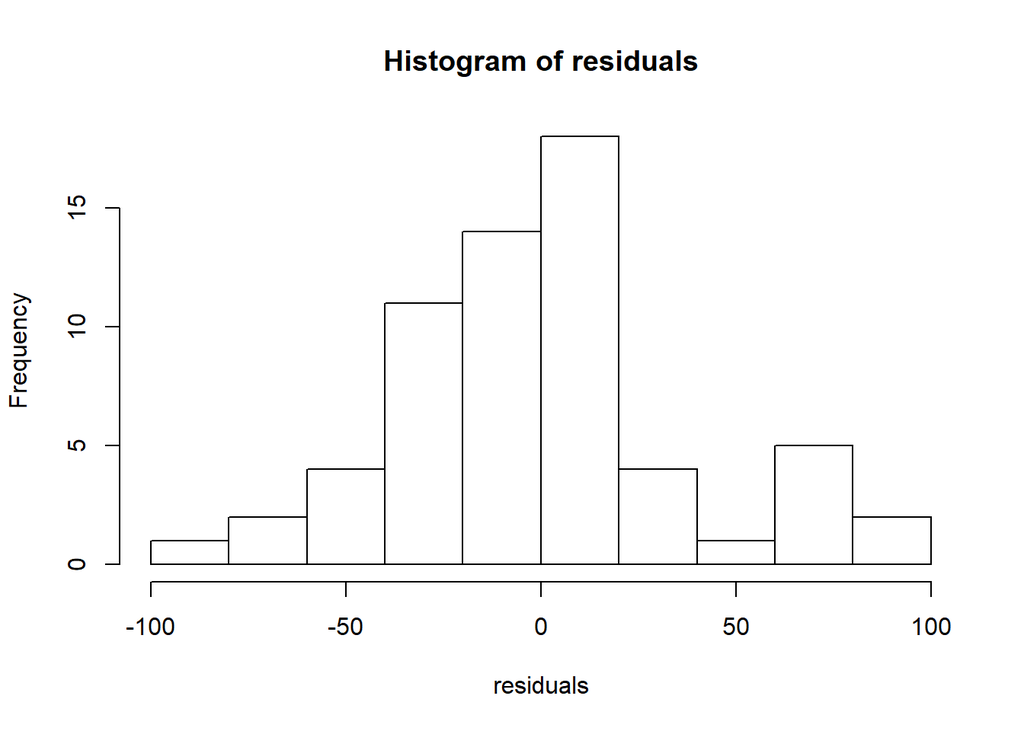

```r
# Expected Values
exp <- fitted.values(fit)

# Observed Values
obs <- beach$OpenBeach

# Residuals
residuals <- obs - exp

# Histogram of the residuals
hist(residuals)
```

```r
# Does it match?... Yes, it does!
summary(fit)
```

```
##
## Call:
## lm(formula = OpenBeach ~ Year * BeachID, data = beach)
##
## Residuals:
##     Min      1Q  Median      3Q     Max
## -80.203 -21.460  -1.434  13.385  89.529
##
## Coefficients:
##                 Estimate Std. Error t value Pr(>|t|)
## (Intercept)    36945.725   2547.493  14.503  < 2e-16 ***
## Year             -18.365      1.272 -14.443  < 2e-16 ***
## BeachIDB      -34211.979   3602.404  -9.497 2.87e-13 ***
## BeachIDC      -28776.115   3602.404  -7.988 8.09e-11 ***
## Year:BeachIDB     17.043      1.798   9.478 3.07e-13 ***
## Year:BeachIDC     14.371      1.798   7.992 7.96e-11 ***
## ---
## Signif. codes:  0 '***' 0.001 '**' 0.01 '*' 0.05 '.' 0.1 ' ' 1
##
## Residual standard error: 39.46 on 56 degrees of freedom
## Multiple R-squared:  0.8298, Adjusted R-squared:  0.8146
## F-statistic: 54.62 on 5 and 56 DF,  p-value: < 2.2e-16
```

```r
summary(residuals)
```

```
##    Min. 1st Qu.  Median    Mean 3rd Qu.    Max.
## -80.203 -21.460  -1.434   0.000  13.385  89.529
```

The histogram seems to follow a Gaussian distribution; however, there is a spike in the right tail which could indicate that it is not normal. This being said, the spike appears small enough for these residuals to reasonably follow a normal distribution.

2. Calculate test statistics for your regression coefficients. Verify by comparing to test statistics reported from model output. (5 points)

```r
# YEAR
b_1 <- coef(fit)[2] # estimate
s_b <- summary(fit)[['coefficients']]['Year', 'Std. Error'] #standard error
B_1 <- 0 # null hypothesis

t <- (b_1 - B_1) / s_b # test statistic
t ## yes, it matches!
```

```
##      Year
## -14.44263
```

```r
############################

# BEACHIDB
b_2 <- coef(fit)[3] #estimate
s_b2 <- summary(fit)[['coefficients']]['BeachIDB', 'Std. Error'] # standard error
B_2 <- 0 # null

t2 <- (b_2 - B_2) / s_b2 # test statistic
t2
```

```
##  BeachIDB
## -9.496986
```

```r
#########################

# BEACHIDC
b_3 <- coef(fit)[4] # estimate
s_b3 <- summary(fit)[['coefficients']]['BeachIDC', 'Std. Error'] # standard error
B_3 <- 0 # null

t3 <- (b_3 - B_3) / s_b3 #test statistic
t3
```

```
##  BeachIDC
## -7.988032
```

```r
#########################

# YEAR:BEACHIDB
b_4 <- coef(fit)[5] #estimate
s_b4 <- summary(fit)[['coefficients']]['Year:BeachIDB', 'Std. Error'] # standard error
B_4 <- 0 # null

t4 <- (b_4 - B_4) / s_b4 # test statistic
t4
```

```
## Year:BeachIDB
##      9.478096
```

```r
#########################

# YEAR:BEACHIDC
b_5 <- coef(fit)[6] # estimate
s_b5 <- summary(fit)[['coefficients']]['Year:BeachIDC', 'Std. Error'] # standard error
B_5 <- 0 #null

t5 <- (b_5 - B_5) / s_b5 # test statistic
t5
```

```
## Year:BeachIDC
##      7.992408
```

```r
###########################
# special one for intercept:

ts_i <- coef(fit)[1] /
summary(fit)[['coefficients']]['(Intercept)', 'Std. Error']
ts_i
```

```
## (Intercept)
##    14.50278
```

```r
##########################
```

Everything matches!

3. Calculate p-values for your regression coefficients. Verify by comparing to p-values reported from model output. What are the associated null hypotheses? Do you reject or fail to reject these null hypotheses? Note: in the lecture slides I reported test statistics are t-distributed with n − 2 degrees of freedom. More generally, these test statistics are t-distributed with n − k degrees of freedom, where k is the number of regression coefficients in your linear model. (5 points)

```r
p <- 2 * (pt(-1 * abs(t), df = 56)) # Reject the null
p2 <- 2 * (pt(-1 * abs(t2), df = 56)) # Reject the null
p3 <- 2 * (pt(-1 * abs(t3), df = 56)) # Reject the null
p4 <- 2 * (pt(-1 * abs(t4), df = 56)) # Reject the null
p5 <- 2 * (pt(-1 * abs(t5), df = 56)) # Reject the null
p6 <- 2 * (pt(-1 * abs(ts_i), df = 56)) # Reject the null

# VERIFY THAT THEY MATCH
summary(fit)[['coefficients']][1, 4] # NULL: At year 0, there is 0 acres of open beach at Beach A.
```

```
## [1] 1.296196e-20
```

```r
summary(fit)[['coefficients']][2, 4] # NULL: Open area of beach A decreases by 0 hectares per year.
```

```
## [1] 1.558806e-20
```

```r
summary(fit)[['coefficients']][3, 4] # NULL: The area of beach B differs from beach A by 0.
```

```
## [1] 2.868075e-13
```

```r
summary(fit)[['coefficients']][4, 4] # NULL: The area of beach B differs from beach A by 0.
```

```
## [1] 8.090204e-11
```

```r
summary(fit)[['coefficients']][5, 4] # NULL: The rate of change for Beach B differs from Beach A by 0.
```

```
## [1] 3.07437e-13
```

```r
summary(fit)[['coefficients']][6, 4] # NULL: The rate of change for Beach C differs from Beach A by 0.
```

```
## [1] 7.957165e-11
```

You reject all of the null hypotheses due to the fact that the p-value is <0.05.

4. Select a single regression coefficient (your choice) and devise a null hypothesis that is different from the default in lm(). Report the test statistics, your p-value, and whether you reject or fail to reject your null hypothesis. (5 points)

```r
# New null: The area of beach C differs from beach A by 100.

b_3 <- coef(fit)[4] #estimate
s_b3 <- summary(fit)[['coefficients']]['BeachIDC', 'Std. Error'] # standard error
B_3 <- 100 # null

t3 <- (b_3 - B_3) / s_b3 # test statistic
t3
```

```
##  BeachIDC
## -8.015791
```

```r
p3 <- 2 * (pt(-1 * abs(t3), df = 56)) # p value
p3
```

```
##    BeachIDC
## 7.28269e-11
```

```r
# Reject the null; therefore beach area of beach c differs from beach a by something other than 100.
```

5. Interpret output of your fitted model. Tell me how beach area does (or does not change) through time at each of the 3 beaches.

The p-value for each co-efficient was <0.05 in every case, and therefore meant that we must reject the null hyspotheses stated in question 3.